# 量的調査（第6回）

Author

藤原翔

Published

October 29, 2023

# 1 媒介分析

$A$を処置，$M$を媒介変数，$Y$をアウトカムとする．Figure 1 のように，$A$へ伸びる矢線がなく$A$の値がランダムに割り当てられているのであれば，$A$から$Y$への因果効果をデータから求めることができる． ここで$A$から$Y$への因果効果は$A \rightarrow Y$と$A \rightarrow M \rightarrow Y$の両方を含んだものである．また同様に$A$から$M$への因果効果をデータから得ることができる．

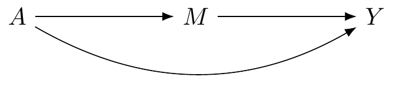

Figure 1: $A$，$M$，$Y$についてのDAG

ここで$A$から$Y$への因果効果を$A \rightarrow Y$と$A \rightarrow M \rightarrow Y$の2つに分解し，$A \rightarrow Y$を$M$を介さない直接効果，$A \rightarrow M \rightarrow Y$を$M$を介した間接効果とする．

ではこのような因果効果の分解は可能なのだろうか． ここで重要なのは$A \rightarrow M \rightarrow Y$は$A \rightarrow M$の効果と$M \rightarrow Y$の効果の2つがあわさったものだということである．先程，$A$から$M$への因果効果をデータから得ることができると述べたが，$A$の値がランダムに割り当てられているのであれば，$M$から$Y$への因果効果を求めることができるのだろうか．

$A$の値がランダムに割り当てられていても，$M$の値がランダムに割り当てられていないのであれば， Figure 2 のようになり$M$から$Y$への因果効果を求めることができない．なお，このDAGでは$A$の値がランダムに割り当てられているので，$A$から$Y$への因果効果は識別可能である．$L$が関わってきそうだが，$M$が合流点となっているため$M$を条件付けなければ$A \rightarrow M \leftarrow L \rightarrow Y$という経路は閉じられたままであるため，$A$から$Y$への因果効果を求めることができるのである．

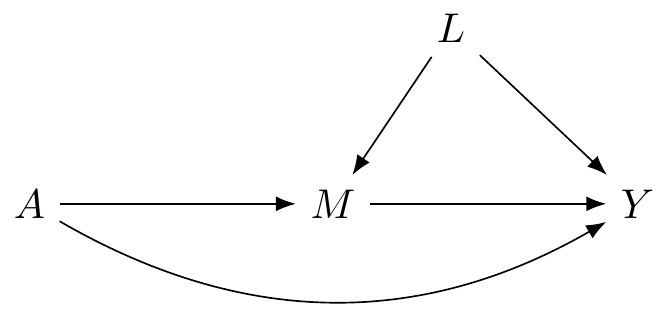

Figure 2: $A$，$M$，$Y$，$L$についてのDAG

一般的には次の Figure 3 のようなDAGを考える．ここでは$C$は$A$と$Y$，$A$と$M$，$M$と$Y$の交絡要因である．先程のDAGにおける$L$も$C$に含まれていると考える．

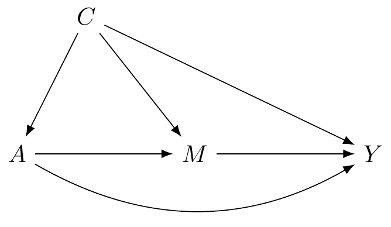

Figure 3: $A$，$M$，$Y$，$C$についてのDAG

## 1.1 線形回帰モデルを用いた方法

Figure 3 は単純な線形回帰モデルの枠組みでは Figure 4 のように描ける．

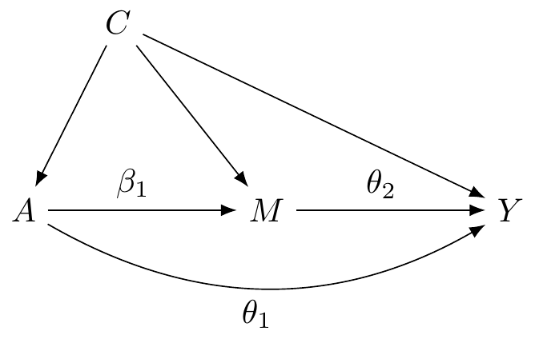

Figure 4: $A$，$M$，$Y$，$C$についてのDAG．単純な線形回帰モデルであるため係数が示されている．

線形モデルであるため，Figure 4 には次の式の係数が加えられている．

$$\begin{align}
M &= \beta_0 + \beta_1 A + \beta_2^\prime C \label{eq:eq-1}\\
Y & = \theta_0 + \theta_1 A + \theta_2 M + \theta_4^\prime C \label{eq:eq-2}\\
\end{align}$$

### 1.1.1 差を用いた方法

差を用いた方法では次のモデルから得られる係数を用いる．

$$\begin{align}
Y & = \phi_0 + \phi_1 A + \phi_4^* C \label{eq:3}
\end{align}$$

これは Figure 5 のように係数つきで描ける．

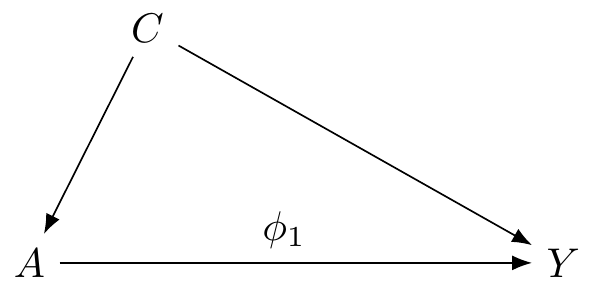

Figure 5: $A$，$Y$，$C$についてのDAG．単純な線形回帰モデルであるため係数が示されている．

$$\begin{align}
\text{IE} & = \phi_1 -\theta_1 \\
\text{DE} & = \theta_1
\end{align}$$

### 1.1.2 積を用いた方法

係数の積を用いて，直接効果と間接効果を次のようにして求める．

$$\begin{align}
\text{IE} & = \beta_1 \theta_2\\
\text{DE} & = \theta_1
\end{align}$$

### 1.1.3 平均処置効果，直接効果，間接効果

$$\begin{align}
\text{TE} & = \phi_1 \nonumber \\
&= \theta_1 + \beta_1 \theta_2 \nonumber \\
&= \text{DE} + \text{IE}
\end{align}$$

### 1.1.4 Rによるシミュレーションと推定

```r
pacman::p_load(tidyverse,
               broom,
               knitr,
               kableExtra,
               lavaan,
               dagitty)
```

```r
# 係数を表示するためのkable関数の設定
my_kable <- function(x, digits = 3){
  knitr::kable(x, digits = digits,
               table.attr = 'data-quarto-disable-processing="true"') |>
  kableExtra::kable_styling(full_width = FALSE)
}
```

シミュレーションデータを作成する．

```r
# シミュレーションデータの設定
set.seed(123456) # 再現性のためのシード値設定
n <- 1000 # サンプルサイズ

# シミュレーションデータの生成
d <- tibble(
  A = rbinom(n, 1, 0.5),        # 処置A: 0または1のランダムな値
  C = rnorm(n),                 # 共変量C: 標準正規分布からのランダムサンプル
  M = 0.5 * A + 0.3 * C + rnorm(n), # Mを作成
  Y = 2 * A + 1.5 * M + 0.5 * A * M + 0.2 * A * C + 0.4 * M * C + rnorm(n) # Yを作成
)

# 最初のいくつかの行を表示してデータを確認
head(d)
```

```
# A tibble: 6 × 4
      A       C      M     Y
  <int>   <dbl>  <dbl> <dbl>
1     1 -0.559   0.476  3.03
2     1  0.991   0.151  2.03
3     0 -0.0430 -0.752 -1.15
4     0  1.67   -1.62  -4.03
5     0 -0.271  -1.46  -2.30
6     0  2.62    1.63   3.00
```

回帰分析によって係数を求め，そこから直接効果と間接効果を求める．

```r
# 重回帰分析
model1_m <- d |> lm(M ~ A + C, data = _) # Mに対するAとCの係数を推定
model1_y_1 <- d |> lm(Y ~ A + C, data = _) # Yに対するAおよびCの係数を推定
model1_y_2 <- d |> lm(Y ~ A + M + C, data = _) # Yに対するA、M、およびCの係数を推定

# 係数の要約
tidy(model1_m)
```

```
# A tibble: 3 × 5
  term        estimate std.error statistic  p.value
  <chr>          <dbl>     <dbl>     <dbl>    <dbl>
1 (Intercept)   0.0229    0.0451     0.507 6.12e- 1
2 A             0.477     0.0635     7.50  1.38e-13
3 C             0.316     0.0317     9.96  2.50e-22
```

```r
tidy(model1_y_1)
```

```
# A tibble: 3 × 5
  term        estimate std.error statistic  p.value
  <chr>          <dbl>     <dbl>     <dbl>    <dbl>
1 (Intercept)    0.144    0.0963      1.49 1.36e- 1
2 A              3.02     0.136      22.3  1.37e-89
3 C              0.791    0.0677     11.7  1.19e-29
```

```r
tidy(model1_y_2)
```

```
# A tibble: 4 × 5
  term        estimate std.error statistic   p.value
  <chr>          <dbl>     <dbl>     <dbl>     <dbl>
1 (Intercept)    0.103    0.0516      1.99 4.71e-  2
2 A              2.16     0.0747     29.0  3.18e-134
3 M              1.80     0.0362     49.8  2.69e-272
4 C              0.222    0.0380      5.83 7.43e-  9
```

```r
# パラメータの抽出
beta_1 <- coef(model1_m)["A"]
phi_1 <- coef(model1_y_1)["A"]
theta_1 <- coef(model1_y_2)["A"]
theta_2 <- coef(model1_y_2)["M"]

# 直接効果、間接効果、および総合効果の計算
de <- theta_1 # 直接効果: A -> Y
ie_1 <- beta_1 * theta_2 # 間接効果: 積
ie_2 <- phi_1 - theta_1  # 間接効果: 差
te_1 <- de + ie_1
te_2 <- phi_1

# 結果の表示
tibble(Estimand = c("DE (theta_1)",
                    "IE (beta_1 * theta_2)",
                    "IE (phi_1 - theta_1)",
                    "TE (DE + IE)",
                    "TE (phi_1)"),
       Estimate = c(de, ie_1, ie_2, te_1, te_2)) |>
  my_kable(4)
```

| Estimand | Estimate |
| --- | --- |
| DE (theta_1) | 2.162 |
| IE (beta_1 * theta_2) | 0.859 |
| IE (phi_1 - theta_1) | 0.859 |
| TE (DE + IE) | 3.021 |
| TE (phi_1) | 3.021 |

## 1.2 パスモデルを用いた方法

パスモデルによるアプローチ．パッケージは`lavaan`を使用する． 標準誤差を直接求められるという利点がある．

```r
model <- '
           # treatment model
           A ~ C
           # mediator model
           M ~ beta_1*A + C
           # outcome model
           Y ~ theta_1*A + theta_2*M + C
           # direct effect
             de := theta_1
           # indirect effect
             ie := beta_1*theta_2
           # total effect
             total := theta_1 + (beta_1*theta_2)'
fit_sem <- sem(model, data = d)
summary(fit_sem)
```

```
lavaan 0.6.16 ended normally after 1 iteration

  Estimator                                         ML
  Optimization method                           NLMINB
  Number of model parameters                         9

  Number of observations                          1000

Model Test User Model:

  Test statistic                                 0.000
  Degrees of freedom                                 0

Parameter Estimates:

  Standard errors                             Standard
  Information                                 Expected
  Information saturated (h1) model          Structured

Regressions:
                   Estimate  Std.Err  z-value  P(>|z|)
  A ~
    C                -0.019    0.016   -1.179    0.238
  M ~
    A       (bt_1)    0.477    0.063    7.515    0.000
    C                 0.316    0.032    9.972    0.000
  Y ~
    A       (th_1)    2.162    0.075   29.011    0.000
    M       (th_2)    1.802    0.036   49.854    0.000
    C                 0.222    0.038    5.843    0.000

Variances:
                   Estimate  Std.Err  z-value  P(>|z|)
   .A                 0.250    0.011   22.361    0.000
   .M                 1.005    0.045   22.361    0.000
   .Y                 1.312    0.059   22.361    0.000

Defined Parameters:
                   Estimate  Std.Err  z-value  P(>|z|)
    de                2.162    0.075   29.011    0.000
    ie                0.859    0.116    7.431    0.000
    total             3.021    0.135   22.318    0.000
```

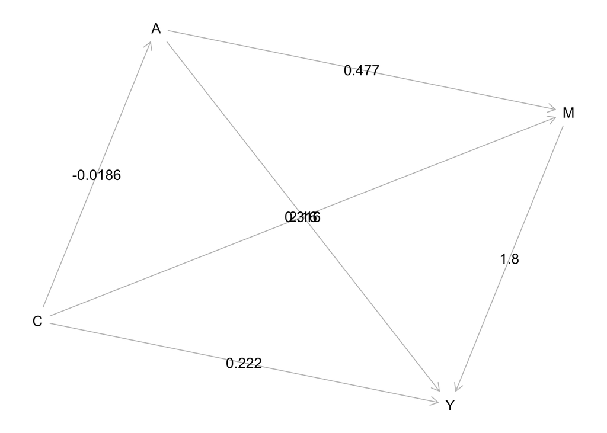

```r
lavaanToGraph(fit_sem) |> plot(show.coefficients = TRUE)
```

### 1.2.1 従来の方法の問題点

次のような場合には直接効果や間接効果を求めることが難しい．

1. 処置と媒介の交互作用がある場合
2. 直線的関係ではない複雑な非線形の関係（高次の交互作用，多項式）がある場合

特に処置と媒介変数は交互作用があると考えられるが，それを考慮しないことによるバイアスも生じる．よほどのことがない限り交互作用があると考えるのが仮定が弱く， データへの当てはまりもよい．交互作用を前提としたリサーチクエスチョンをたてることも興味深い．

$$\begin{align}
Y & = \theta_0 + \theta_1 A + \theta_2 M + \theta_3 AM + \theta_4^\prime C \label{eq:eq-4}
\end{align}$$

```r
model1_y_3 <- d |> lm(Y ~ A * M + C, data = _) # Yに対するA、M、およびCの係数を推定
tidy(model1_y_3)
```

```
# A tibble: 5 × 5
  term        estimate std.error statistic   p.value
  <chr>          <dbl>     <dbl>     <dbl>     <dbl>
1 (Intercept)    0.113    0.0499      2.27 2.34e-  2
2 A              2.02     0.0741     27.2  1.66e-122
3 M              1.51     0.0493     30.5  4.90e-145
4 C              0.219    0.0368      5.95 3.61e-  9
5 A:M            0.566    0.0668      8.48 8.12e- 17
```

線形モデルの係数ベースで直接効果や間接効果が定義されていると， 応用がきかない．

## 1.3 因果媒介分析へ

媒介分析は処置がアウトカムに対してもつ因果効果を，媒介変数を経由しないものと経由するものに分解する．媒介分析は因果の連鎖を含んだ分析であるため，まず効果を回帰モデルの係数ではなくポテンシャルアウトカムから定義する．

他の因果推論でも同様だが，理論的エスティマンドの設定，識別のための条件の確認，経験的エスティマンドの設定，推定という形で理論と推定の段階を分けて考える必要がある (Lundberg 2022)．このような因果推論をベースとした媒介分析を因果媒介分析（causal mediation analysis）と呼ぶ．

# 2 ポテンシャルアウトカム

- 処置を$A$，媒介要因を$M$，アウトカムを$Y$とする．
- 個人$i$については処置は$A_i$，媒介要因は$M_i$，アウトカムは$Y_i$とする．
- $Y_i^a$: $A=a$としたときの個人$i$の$Y$についてのポテンシャルアウトカム
- $M_i^a$: $A=a$としたときの個人$i$の$M$についてのポテンシャルアウトカム
- $Y_i^{am}$: $A=a$かつ$M=m$としたときの個人$i$の$Y$についてのポテンシャルアウトカム
  - $Y_i^{11}$：$a=1$かつ$m=1$
  - $Y_i^{01}$：$a=0$かつ$m=1$
  - $Y_i^{10}$：$a=1$かつ$m=0$
  - $Y_i^{00}$：$a=0$かつ$m=0$

# 3 構成性（composition）

$$\begin{align}
Y^a = Y^{aM^a}
\end{align}$$

つまり$Y^1 = Y^{1M^1}$や$Y^0 = Y^{0M^0}$が成り立つ．

処置が$a$と$a^*$についての平均因果効果を考える．

$$\begin{align}
TE(a, a^*) &= E[Y^a - Y^{a^*}] \nonumber \\
&= E[Y^{aM^a} - Y^{a^* M^{a^*}}]
\end{align}$$

# 4 制御直接効果

## 4.1 エスティマンド

媒介変数を$m$としたときの制御直接効果（controlled direct effect）は次のように定義される．

$$\begin{align}
CDE(a, a^*, m) = E[Y^{am}-Y^{a^* m}]
\end{align}$$

制御直接効果の値は$M=m$をどのような値に設定するのかによって異なる可能性がある．

## 4.2 識別の条件

制御処置効果の識別には次の条件が満たされている必要がある．

1. $Y^{am} \perp \!\!\! \perp A|C \quad \text{(C1)}$
2. $Y^{am} \perp \!\!\! \perp M|A,C \quad \text{(C2)}$

$$\begin{align}
E[Y^{am}-Y^{a^* m}|c] &= E[Y^{am}|a,c] - E[Y^{a^* m}|a^*,c] \quad (\because \text{C1})\nonumber \\
&= E[Y^{am}|a,m,c] - E[Y^{a^* m}|a^*,m,c] \quad (\because \text{C2}) \nonumber \\
&= E[Y|a,m,c] - E[Y|a^*,m,c]
\end{align}$$

よって平均的な制御直接効果は次のようになる．

$$\begin{align}
E[Y^{am}-Y^{a^* m}] &= E_c[E[Y^{am}-Y^{a^* m}|c]]\\
&= E_c[E[Y|a,m,c] - E[Y|a^*,m,c]]
\end{align}$$

## 4.3 推定

$$\begin{align}
CDE(a, a^*, m) &= E[Y|a,m,c] - E[Y|a^*,m,c] \\
&= (\theta_0 + \theta_1 a + \theta_2 m + \theta_3 am + \theta_4^\prime c)-
(\theta_0 + \theta_1 a^* + \theta_2 m + \theta_3 a^* m + \theta_4^\prime c) \\
&=
(\theta_1 + \theta_3 m)(a - a^*)
\end{align}$$

つまり，$m=0$の時，$CDE(a, a^*, 0)= \theta_1$であり， $m=1$の時，$CDE(a, a^*, 1)= \theta_1 + \theta_3$である． また$C=c$の値に依存しない．

## 4.4 Rによる推定

```r
# 結果の表示
theta_1 <- coef(model1_y_3)["A"]
theta_3 <- coef(model1_y_3)["A:M"]
tibble(Etimand = c( "CDE(0)",  "CDE(1)"),
       Estimate = c(theta_1, theta_1 + theta_3)) |>
  my_kable()
```

| Etimand | Estimate |
| --- | --- |
| CDE(0) | 2.019 |
| CDE(1) | 2.585 |

# 5 自然な直接効果と間接効果

参考文献としては Valeri and VanderWeele (2013), Vanderweele and Vansteelandt (2009)，VanderWeele, Vansteelandt, and Robins (2014), Wodtke and Zhou (2020) などを参照．

介入するのではなく媒介変数が処置を受けた後に自然にとる値を考える．ここでは4つのポテンシャルアウトカムを考える．

- $Y_i^{aM^a} = Y_i^a$：$a$かつ$M^a$なので結局$a$のときの$Y_i$
- $Y_i^{a^* M^{a^*}} = Y_i^{a^*}$：$a^*$かつ$M^{a^*}$なので結局$a^*$のときの$Y_i$
- $Y_i^{aM^{a^*}}$：$a$かつ$M^{a^*}$という交差世界のポテンシャルアウトカム
- $Y_i^{a^* M^{a}}$：$a^*$かつ$M^{a}$という交差世界のポテンシャルアウトカム

例えば$a = 0, 1$の時を考えると次のようになる．

- $Y_i^{a = 1M^{a = 1}} = Y_i^1$：$a=1$かつ$M^{a = 1}$なので結局$a=1$のときの$Y_i$
- $Y_i^{a = 0 M^{a = 0}} = Y_i^{a = 0}$：$a=0$かつ$M^{a=0}$なので結局$a=0$のときの$Y_i$
- $Y_i^{a=1M^{a=0}}$：$a=1$かつ$M^{a=0}$のときの$Y_i$という交差世界のポテンシャルアウトカム
- $Y_i^{a=0 M^{a=1}}$：$a=0$かつ$M^{a=1}$のときの$Y_i$という交差世界のポテンシャルアウトカム

制御直接効果については$M$を何らかの値に設定したが， ここでは処置を受けたときに自然にとる媒介の値に設定する．

直接効果は媒介変数を一定としたときに処置を変化させるとどのようになるのか， 間接効果は処置を一定としたときに媒介変数を変化させるとアウトカムがどのようになるのかを示す．

## 5.1 エスティマンド

### 5.1.1 純粋自然直接効果（pure natural direct effect）

純粋自然直接効果は，媒介変数を処置がなかったときの値$M^{a=0}$で一定としたときに，処置を変化させたときの効果である．

$$\begin{align}
PNDE = E[Y^{a=1M^{a=0}}] - E[Y^{a=0M^{a=0}}]
\end{align}$$

### 5.1.2 総合自然間接効果（total natural indirect effect）

総合自然間接効果は，処置を$a=1$で一定とさせたときに媒介変数を処置がなかったときの値$M^{a=0}$から処置があったときの値$M^{a=1}$に変化させたときの効果である．総合効果は純粋効果と交互作用効果の両方を含んでいる．したがって後に述べるように，$TNIE$は更に分解することが可能である．

### 5.1.3 総合自然直接効果（total natural direct effect）

$$\begin{align}
TNDE = E[Y^{a=1M^{a=1}}] - E[Y^{a=0M^{a=1}}]
\end{align}$$

### 5.1.4 純粋自然間接効果（pure natural indirect effect）

純粋自然直接効果は，処置を$a=0$で一定とさせたときに媒介変数を処置がなかったときの値$M^{a=0}$から処置があったときの値$M^{a=1}$に変化させたときの効果である．

$$\begin{align}
PNIE = E[Y^{a=0M^{a=1}}] - E[Y^{a=0M^{a=0}}]
\end{align}$$

### 5.1.5 平均処置効果と自然な直接効果と間接効果

純粋自然直接効果と総合自然間接効果の和は平均処置効果となる．

$$\begin{align}
& E[Y^{a=1M^{a=0}}] - E[Y^{a=0M^{a=0}}] + E[Y^{a=1M^{a=1}}] - E[Y^{a=1M^{a=0}}] \nonumber \\
& \quad= E[Y^{a=1M^{a=1}}] - E[Y^{a=0M^{a=0}}] \nonumber\\
& \quad= E[Y^{a=1}] - E[Y^{a=0}]
\end{align}$$

同様に総合自然直接効果と純粋自然間接効果の和は平均処置効果となる．

$$\begin{align}
&E[Y^{a=1M^{a=1}}] - E[Y^{a=0M^{a=1}}] + E[Y^{a=0M^{a=1}}] - E[Y^{a=0M^{a=0}}] \nonumber \\
& \quad = E[Y^{a=1M^{a=1}}] - E[Y^{a=0M^{a=0}}] \nonumber\\
& \quad = E[Y^{a=1}] - E[Y^{a=0}]
\end{align}$$

## 5.2 識別の条件

制御直接効果に加えて2つの条件がある． そのうちのひとつは$A$から$M$への因果効果の識別に関するものである． 残りのひとつは交差世界独立（cross-world independence）の仮定と呼ばれるものであり， 実験であっても検証ができない仮定である．

1. $Y^{am} \perp \!\!\! \perp A|C$
2. $Y^{am} \perp \!\!\! \perp M|A,C$
3. $M^{a} \perp \!\!\! \perp A|C$
4. $Y^{am} \perp \!\!\! \perp M^{a^*}|A,C$

これは処置の影響をうける媒介ーアウトカムの交絡がないという仮定となる． 一般的にはこのような状態が成り立ちにくく， 自然な直接効果と間接効果を識別できないことのほうが多い．

交差世界における量を求める必要がある．それは，次の媒介公式（mediation formula）によって求めることができる．
$$\begin{align}
E[Y^{a M^{a^*}}|c]
&= \sum_m E[Y^{am}|M^{a^*} = m, c]\Pr(M^{a^*}=m|c) \nonumber \\
& = \sum_m E[Y^{a m}|c]\Pr(M^{a^*}=m|a^*, c)\nonumber\\
& = \sum_m E[Y^{a m}|a,c]\Pr(M=m|a^*, c)\nonumber\\
& = \sum_m E[Y^{a m}|a,m,c]\Pr(m|a^*, c)\nonumber\\
& = \sum_m E[Y|a,m,c]\Pr(m|a^*, c)
\end{align}$$

$$\begin{align}
E[Y^{a M^{a}}|c] = \sum_m E[Y|a,m,c]\Pr(m|a, c)
\end{align}$$

$$\begin{align}
E[Y^{a^* M^{a^*}}|c] = \sum_m E[Y|a^*,m,c]\Pr(m|a^*, c)
\end{align}$$

よって$PNDE$と$TNIE$は次のようになる．

$$\begin{align}
PNDE & = E[Y^{aM^{a^*}} - Y^{a^* M^{a^*}}] \\
& = \sum_{m,c} \{E[Y|a,m,c] - E[Y|a^*, m, c] \} \Pr(m|a^*, c) \Pr(c)
\end{align}$$

$$\begin{align}
TNIE &= E[Y^{aM^{a}} - Y^{a M^{a^*}}] \\
& = \sum_{m,c} E[Y|a,m,c] \{\Pr(m|a, c) - \Pr(m|a^*, c) \} \Pr(c)
\end{align}$$

同様に$TNDE$と$PNIE$は次のようになる．

$$\begin{align}
TNDE & = E[Y^{aM^a} - Y^{a^* M^{a}}] \\
& = \sum_{m,c} \{E[Y|a,m,c] - E[Y|a^*, m, c] \} \Pr(m|a, c) \Pr(c)
\end{align}$$

$$\begin{align}
PNIE &= E[Y^{a^* M^{a}} - Y^{a^* M^{a^*}}] \\
& = \sum_{m,c} E[Y|a^*,m,c] \{\Pr(m|a, c) - \Pr(m|a^*, c) \} \Pr(c)
\end{align}$$

## 5.3 推定

単純な線形回帰モデルの場合，$C=c$のときの自然な直接効果と間接効果は次のように推定できる． 証明については Vanderweele and Vansteelandt (2009) のApp．

$$\begin{align}
PNDE &= \{\theta_1 + \theta_3 (\beta_0 + \beta_1 a^* + \beta^*_2c)\}(a - a^*) \nonumber\\
& = (\theta_1 + \theta_3 \beta_0 + \theta_3\beta_1 a^* +\theta_3 \beta^*_2c)(a - a^*)
\end{align}$$

もし処置$A$と媒介要因$M$に交互作用がなければ$\theta_3 = 0$であるため，$PNDE = \theta_1 (a - a^*)$となり，$CDE$と一致する．

$$\begin{align}
TNIE = (\theta_2 \beta_1 + \theta_3 \beta_1 a)(a - a^*)
\end{align}$$

もし処置$A$と媒介要因$M$に交互作用がなければ$\theta_3 = 0$であるため，$TNIE =\theta_2 \beta_1(a - a^*)$となる．

同様にして，$TNDE$と$PNIE$は次のようになる．

$$\begin{align}
TNDE &= \{\theta_1 + \theta_3 (\beta_0 + \beta_1 a + \beta^*_2c)\}(a - a^*) \nonumber\\
& = (\theta_1 + \theta_3 \beta_0 + \theta_3\beta_1 a +\theta_3 \beta^*_2c)(a - a^*) \\
PNIE &= \beta_1(\theta_2 + \theta_3 a^*)(a - a^*) \nonumber\\
&= (\theta_2 \beta_1 + \theta_3 \beta_1 a^*)(a - a^*)
\end{align}$$

## 5.4 Rによる推定

まずはシンプルな処置と媒介の交互作用のある回帰モデルで自然な直接効果と間接効果を求めてみる． 詳細については Valeri and VanderWeele (2013) を参照．

```r
# パラメータの抽出
phi_1 <- coef(model1_y_1)["A"]
theta_1 <- coef(model1_y_3)["A"]
theta_2 <- coef(model1_y_3)["M"]
theta_3 <- coef(model1_y_3)["A:M"]
beta_0 <- coef(model1_m)["(Intercept)"]
beta_1 <- coef(model1_m)["A"]
beta_2_prime <- coef(model1_m)["C"]

# a, a* の設定
# ここでは a として A の平均を、a* として 0 (介入なし) を採用
a <- 1
a_star <- 0

# C の平均を計算
c <- mean(d$C)

# TE の計算
te <- coef(model1_y_1)["A"]

# PNDE の計算
pnde <- (theta_1 + theta_3 * (beta_0 + beta_1 * a_star + beta_2_prime * c)) * (a - a_star)

# TNDE の計算
tnde <- (theta_1 + theta_3 * (beta_0 + beta_1 * a + beta_2_prime * c)) * (a - a_star)

# PNIE の計算
pnie <- beta_1 * (theta_2 + theta_3 * a_star) * (a - a_star)

# TNIE の計算
tnie <- beta_1 * (theta_2 + theta_3 * a) * (a - a_star)

# 結果の表示
tibble(estimand = c("CDE(0)",
                    "CDE(1)",
                    "PNDE", "TNDE", "PNIE", "TNIE",
                    "TE = PNDE + TNIE",
                    "TE = TNDE + PNIE", "TE (phi_1)"),
       estimate = c(theta_1,
                    theta_1 + theta_3,
                    pnde, tnde, pnie, tnie, pnde + tnie, tnde + pnie, phi_1)) |>
  my_kable()
```

| estimand | estimate |
| --- | --- |
| CDE(0) | 2.019 |
| CDE(1) | 2.585 |
| PNDE | 2.032 |
| TNDE | 2.302 |
| PNIE | 0.718 |
| TNIE | 0.988 |
| TE = PNDE + TNIE | 3.020 |
| TE = TNDE + PNIE | 3.020 |
| TE (phi_1) | 3.021 |

処置$A$と媒介変数$M$に交互作用がないというモデルを考えるとどうなるだろうか． 交互作用のないモデルのパラメータを使用し，また$\theta_3 = 0$としてエスティマンドを推定する．

```r
# パラメータの抽出
phi_1 <- coef(model1_y_1)["A"]
theta_1 <- coef(model1_y_2)["A"]
theta_2 <- coef(model1_y_2)["M"]
theta_3 <- 0
beta_0 <- coef(model1_m)["(Intercept)"]
beta_1 <- coef(model1_m)["A"]
beta_2_prime <- coef(model1_m)["C"]

# a, a* の設定
# ここでは a として A の平均を、a* として 0 (介入なし) を採用
a <- 1
a_star <- 0

# C の平均を計算
c <- mean(d$C)

# TE の計算
te <- coef(model1_y_1)["A"]

# PNDE の計算
pnde <- (theta_1 + theta_3 * (beta_0 + beta_1 * a_star + beta_2_prime * c)) * (a - a_star)

# TNDE の計算
tnde <- (theta_1 + theta_3 * (beta_0 + beta_1 * a + beta_2_prime * c)) * (a - a_star)

# PNIE の計算
pnie <- beta_1 * (theta_2 + theta_3 * a_star) * (a - a_star)

# TNIE の計算
tnie <- beta_1 * (theta_2 + theta_3 * a) * (a - a_star)

# 結果の表示
tibble(estimand = c("CDE(0)",
                    "CDE(1)",
                    "PNDE", "TNDE", "PNIE", "TNIE",
                    "TE = PNDE + TNIE",
                    "TE = TNDE + PNIE", "TE (phi_1)"),
       estimate = c(theta_1,
                    theta_1 + theta_3,
                    pnde, tnde, pnie, tnie, pnde + tnie, tnde + pnie, phi_1)) |>
  my_kable()
```

| estimand | estimate |
| --- | --- |
| CDE(0) | 2.162 |
| CDE(1) | 2.162 |
| PNDE | 2.162 |
| TNDE | 2.162 |
| PNIE | 0.859 |
| TNIE | 0.859 |
| TE = PNDE + TNIE | 3.021 |
| TE = TNDE + PNIE | 3.021 |
| TE (phi_1) | 3.021 |

$CDE$，$PNDE$，$TNDE$がすべて等しいことがわかる．

## 5.5 CMAverseパッケージ

https://bs1125.github.io/CMAverse/ を参照．

`model = "rb"`で`estimation = "paramfunc"`とすれば回帰分析ベースによる Valeri and VanderWeele (2013) の方法で推定が可能である．

```r
library(CMAverse)
fit_cmest <-
  cmest(data = d,
      model = "rb",
      outcome = "Y",
      exposure = "A",
      mediator = "M",
      basec = "C",
      EMint = TRUE,
      astar = 0,
      a = 1,
      mval = list(1),
      mreg = list("linear"),
      yreg = "linear",
      estimation = "paramfunc",
      inference = "delta")
```

推定値のみを取り出す．

```r
summary(fit_cmest)$summarydf |>
  my_kable()
```

|  | Estimate | Std.error | 95% CIL | 95% CIU | P.val |
| --- | --- | --- | --- | --- | --- |
| cde | 2.585 | 0.088 | 2.413 | 2.757 | 0 |
| pnde | 2.032 | 0.078 | 1.879 | 2.185 | 0 |
| tnde | 2.302 | 0.078 | 2.149 | 2.455 | 0 |
| pnie | 0.718 | 0.099 | 0.525 | 0.912 | 0 |
| tnie | 0.988 | 0.134 | 0.726 | 1.250 | 0 |
| te | 3.020 | 0.135 | 2.756 | 3.284 | 0 |
| intref | -0.553 | 0.070 | -0.690 | -0.416 | 0 |
| intmed | 0.270 | 0.048 | 0.176 | 0.364 | 0 |
| cde(prop) | 0.856 | 0.037 | 0.783 | 0.929 | 0 |
| intref(prop) | -0.183 | 0.023 | -0.228 | -0.138 | 0 |
| intmed(prop) | 0.089 | 0.014 | 0.062 | 0.116 | 0 |
| pnie(prop) | 0.238 | 0.025 | 0.189 | 0.286 | 0 |
| pm | 0.327 | 0.033 | 0.262 | 0.392 | 0 |
| int | -0.094 | 0.016 | -0.125 | -0.062 | 0 |
| pe | 0.144 | 0.037 | 0.071 | 0.217 | 0 |

# 6 ランダム化類似の自然な直接・間接効果

Figure 6 ようなDAGの場合，(4) $Y^{am} \perp \!\!\! \perp M^{a^*}|A,C$つまり交差世界における$M^{a^*}$と$Y^{am}$の独立が成り立たない． このような$L$は処置の影響を受ける媒介ーアウトカムの交絡要因（treatment-induced confounder）である．

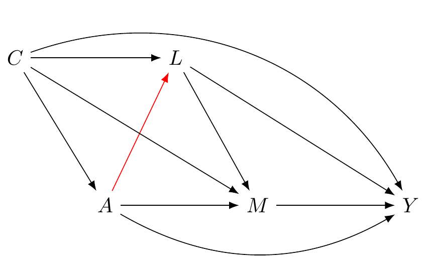

Figure 6: $A$，$Y$，$M$，$C$，$L$についてのDAG．”

## 6.1 ポテンシャルアウトカム

$C=c$という共変量のもとで，$A=a$と設定されたときの$M$の分布からランダムに選んだ$M$の値を次のように示す．

$$\begin{equation}
G^{a|c}
\end{equation}$$

この時，$Y$のポテンシャルアウトカムは次のようになる．

$$\begin{equation}
Y^{a G^{a|c}}
\end{equation}$$

これは自然な$Y^{a M^{a}}=Y^a$とは異なることに注意せよ．

同様にすれば，$Y^{a^* G^{a^*|c}}$を定義でき，また$Y^{a G^{a^*|c}}$や$Y^{a^* G^{a|c}}$を定義することができる．

## 6.2 エスティマンド

### 6.2.1 総合効果（overall effect）

$$\begin{align}
TE^R &= E[Y^{a G^{a|c}}] - E[Y^{a^* G^{a^*|c}}]\\
& \neq E[Y^{a G^{a|c}}] - E[Y^{a^* G^{a^*|c}}] = TE
\end{align}$$

### 6.2.2 ランダム類似の純粋自然直接効果（pure natural direct effect）

ランダム類似の純粋自然直接効果は，媒介変数を共変量が$c$で処置が$a$の時の$M$の分布$G^{a^*|c}$からランダムに値を抽出したときに，処置を$a^*$から$a$に変化させたときの効果である．

$$\begin{align}
PNDE^R &= E[Y^{aG^{a^* |c}}] - E[Y^{a^* G^{a^* |c}}] \\
&= \sum_{c,l,m} \{E[Y|a,l,m,c]\Pr(l|a,c) - E[Y|a^*,l,m,c]\Pr(l|a^*,c) \} \Pr(m|a^*,c)\Pr(c)
\end{align}$$

### 6.2.3 ランダム類似の総合自然間接効果（total natural indirect effect）

ランダム類似の総合自然間接効果は，処置を$a$で一定とさせたときに媒介変数を共変量が$c$で処置が$a$の時の$M$の分布$G^{a^*|c}$からランダムに値を抽出した値と 処置が$a^*$の時の$M$の分布$G^{a^*|c}$からランダムに値を抽出した値を比較して得られる効果である．

$$\begin{align}
TNIE^R &= E[Y^{aG^{a |c}}] - E[Y^{a G^{a^*|c}}] \\
&= \sum_{c,l,m} E[Y|a,l,m,c]\Pr(l|a,c) \{ \Pr(m|a,c) - \Pr(m|a^*,c)\}\Pr(c)
\end{align}$$

### 6.2.4 ランダム類似の総合自然直接効果（total natural direct effect）

ランダム類似の総合自然直接効果は，媒介変数を共変量が$c$で処置が$a$の時の$M$の分布$G^{a|c}$からランダムに値を抽出したときに，処置を$a^*$から$a$に変化させたときの効果である．

$$\begin{align}
TNDE^R &= E[Y^{aG^{a |c}}] - E[Y^{a^*G^{a |c}}] \\
&= \sum_{c,l,m} \{E[Y|a,l,m,c]\Pr(l|a,c) - E[Y|a^*,l,m,c]\Pr(l|a^*,c) \} \Pr(m|a,c)\Pr(c)
\end{align}$$

### 6.2.5 ランダム類似の純粋自然間接効果（pure natural indirect effect）

ランダム類似の純粋自然間接効果は，処置を$a^*$で一定とさせたときに媒介変数を共変量が$c$で処置が$a$の時の$M$の分布$G^{a^*|c}$からランダムに値を抽出した値と 処置が$a^*$の時の$M$の分布$G^{a^*|c}$からランダムに値を抽出した値を比較して得られる効果である．

$$\begin{align}
PNIE^R &= E[Y^{a^* G^{a|c}}] - E[Y^{a^* G^{a^*|c}}] \\
&= \sum_{c,l,m} E[Y|a^*,l,m,c]\Pr(l|a^*,c) \{ \Pr(m|a,c) - \Pr(m|a^*,c)\}\Pr(c)
\end{align}$$

## 6.3 識別の条件

自然な直接・間接効果とは異なり，交差世界独立（cross-world independence）の仮定は必要ない．つまり，媒介ーアウトカムの交絡要因 処置$A$に影響をうけるような変数$L$があってもよい．

1. $Y^{am} \perp \!\!\! \perp A|C$
2. $Y^{am} \perp \!\!\! \perp M|A,C,L$
3. $M^{a} \perp \!\!\! \perp A|C$

## 6.4 推定

これまで用いている回帰モデルの係数をもちいてランダム化類似の効果を求めることはできない． そこで，残差を用いた回帰分析（RWR: Regression with Residuals）とG-Formulaの2つを用いる．

RWRをベースとした証明は Wodtke and Zhou (2020) のApp．

## 6.5 Rによる推定

では新たなデータを作成する．

```r
# シミュレーションデータの設定
set.seed(123456) # 再現性のためのシード値設定
n <- 1000 # サンプルサイズ

# シミュレーションデータの生成
d_L <- tibble(
  A = rbinom(n, 1, 0.5),        # 処置A: 0または1のランダムな値
  C = rnorm(n),                 # 共変量C: 標準正規分布からのランダムサンプル
) |>
  mutate(
    L = 0.3 * A + rnorm(n),     # Lを作成: Aに依存する
    M = 0.5 * A + 0.3 * C + 0.2 * L + rnorm(n), # Mを作成: Lにも依存するように修正
    Y = 2 * A + 1.5 * M + 0.5 * A * M + 0.2 * A * C + 0.4 * M * C + 0.3 * L + rnorm(n) # Yを作成: Lにも依存するように修正
  )
```

### 6.5.1 通常の回帰分析の限界

通常の回帰分析による方法では求めることができない．

```r
model2_m <- d_L |> lm(M ~ A + C + L, data = _) # Mに対するAとCの係数を推定
model2_y_1 <- d_L |> lm(Y ~ A + C, data = _) # Yに対するAおよびCの係数を推定
model2_y_2 <- d_L |> lm(Y ~ A + M + C + L, data = _) # Yに対するA、M、およびCの係数を推定
model2_y_3 <- d_L |> lm(Y ~ A * M + C + L, data = _) # Yに対するA、M、およびCの係数を推定

# パラメータの抽出
phi_1 <- coef(model2_y_1)["A"]
theta_1 <- coef(model2_y_3)["A"]
theta_2 <- coef(model2_y_3)["M"]
theta_3 <- coef(model2_y_3)["A:M"]
beta_0 <- coef(model2_m)["(Intercept)"]
beta_1 <- coef(model2_m)["A"]
beta_2_prime <- coef(model2_m)["C"]
beta_3_prime <- coef(model2_m)["L"]

# a, a* の設定
# ここでは a として A の平均を、a* として 0 (介入なし) を採用
a <- 1
a_star <- 0

# CとLの平均を計算
c <- mean(d_L$C)
l <- mean(d_L$L)

# TE の計算
te <- coef(model2_y_1)["A"]

# PNDE の計算
pnde <- (theta_1 + theta_3 * (beta_0 + beta_1 * a_star + beta_2_prime * c + beta_3_prime * l)) * (a - a_star)

# TNDE の計算
tnde <- (theta_1 + theta_3 * (beta_0 + beta_1 * a + beta_2_prime * c)) * (a - a_star)

# PNIE の計算
pnie <- beta_1 * (theta_2 + theta_3 * a_star) * (a - a_star)

# TNIE の計算
tnie <- beta_1 * (theta_2 + theta_3 * a) * (a - a_star)

# 結果の表示
tibble(estimand = c("CDE(0)",
                    "CDE(1)",
                    "PNDE", "TNDE", "PNIE", "TNIE",
                    "TE = PNDE + TNIE",
                    "TE = TNDE + PNIE",
                    "TE (phi_1)"),
       estimate = c(theta_1,
                    theta_1 + theta_3,
                    pnde, tnde, pnie, tnie, pnde + tnie, tnde + pnie, te)) |>
  my_kable()
```

| estimand | estimate |
| --- | --- |
| CDE(0) | 2.062 |
| CDE(1) | 2.697 |
| PNDE | 2.088 |
| TNDE | 2.397 |
| PNIE | 0.729 |
| TNIE | 1.062 |
| TE = PNDE + TNIE | 3.151 |
| TE = TNDE + PNIE | 3.126 |
| TE (phi_1) | 3.372 |

### 6.5.2 RWR: Regression with Residuals

残差を用いた回帰分析（Regression with Residuals）による方法

```r
# 重回帰分析
d_L <- d_L |>
  mutate(M = M - mean(M),
         res_C = C - mean(C))
model3_l <- d_L |> lm(L ~ A + C, data = _) # Mに対するAとCの係数を推定
d_L <- d_L |>
  mutate(res_L = residuals(model3_l))

model3_m <- d_L |> lm(M ~ A + res_C, data = _)
model3_y_rwr <- d_L |> lm(Y ~ A + M + A*M + res_C + res_L, data = _)

beta_0 <- coef(model3_m)["(Intercept)"]
beta_1 <- coef(model3_m)["A"]

theta_1 <- coef(model3_y_rwr)["A"]
theta_2 <- coef(model3_y_rwr)["M"]
theta_3 <- coef(model3_y_rwr)["A:M"]

# a, a* の設定
a <- 1
a_star <- 0

# 結果の表示
# PNDE の計算
pnde_r <- (theta_1 + theta_3 * (beta_0 + beta_1 * a_star)) * (a - a_star)

# TNDE の計算
tnde_r <- (theta_1 + theta_3 * (beta_0 + beta_1 * a)) * (a - a_star)

# PNIE の計算
pnie_r <- beta_1 * (theta_2 + theta_3 * a_star) * (a - a_star)

# TNIE の計算
tnie_r <- beta_1 * (theta_2 + theta_3 * a) * (a - a_star)

# 結果の表示
tibble(estimand = c("CDE(0)", "CDE(1)", "PNDE", "TNDE", "PNIE", "TNIE",
                    "TE = PNDE + TNIE",
                    "TE = TNDE + PNIE"),
       estimate = c(theta_1, theta_1 + theta_3,
                    pnde_r, tnde_r, pnie_r, tnie_r,
                    pnde_r + tnie_r, tnde_r + pnie_r)) |>
  my_kable()
```

| estimand | estimate |
| --- | --- |
| CDE(0) | 2.362 |
| CDE(1) | 2.998 |
| PNDE | 2.173 |
| TNDE | 2.549 |
| PNIE | 0.822 |
| TNIE | 1.198 |
| TE = PNDE + TNIE | 3.370 |
| TE = TNDE + PNIE | 3.370 |

`rwrmed`パッケージを用いる．

```r
library(rwrmed)
treatment <- "A"
pre_cov <- "C"
y_form <- Y ~ A + M + A*M + C + L
m_form <- M ~ A + C
l1 <- lm(L ~ A + C, data = d_L)
fit_rwr <-
  rwrmed(treatment = treatment, pre_cov = pre_cov, zmodels = list(l1),
  y_form = y_form, m_form = m_form, data = d_L)
fit_rwr
```

```
$y_model

Call:
lm(formula = y_form, data = data_ed, weights = weights)

Coefficients:
(Intercept)            A            M            C            L          A:M
     0.5481       2.3624       1.3882       0.2641       0.3814       0.6351


$m_model

Call:  glm(formula = m_form, family = m_family, data = data_ed, weights = weights)

Coefficients:
(Intercept)            A            C
    -0.2990       0.5920       0.3215

Degrees of Freedom: 999 Total (i.e. Null);  997 Residual
Null Deviance:      1216
Residual Deviance: 1032     AIC: 2877

$zmodels
$zmodels[[1]]

Call:
lm(formula = L ~ A + C, data = d_L)

Coefficients:
(Intercept)            A            C
    0.02288      0.27677      0.01597



$var_names
$var_names$treatment
[1] "A"

$var_names$mediator
[1] "M"
```

[output cut: 34 more lines]

[output not shown]

```r
fit_rwr |> decomp()
```

```
..................................................
```

```
$twocomp
     Estimate         SE 2.5% Perc 97.5% Perc
rNDE 2.172555 0.08515438 2.0137116   2.350289
rNIE 1.197847 0.13178565 0.9539215   1.460265
rATE 3.370402 0.13794451 3.1148815   3.643333

$fourcomp
          Estimate         SE  2.5% Perc 97.5% Perc
CDE      2.3624330 0.07677711  2.2231307  2.5199887
rINTREF -0.1898780 0.04029392 -0.2668227 -0.1169610
rPIE     0.8218507 0.09023961  0.6513708  1.0014544
rINTMED  0.3759961 0.06605016  0.2573576  0.5101578
rATE     3.3704018 0.13794451  3.1148815  3.6433331
```

### 6.5.3 G-Formulaを用いた方法

`CMAverse`パッケージを用いる．モデルとして`rb`はつかえないので`gformula`とする．

G-Formulaではモデルからポテンシャルアウトカムを予測し，エスティマンドを推定する．

```r
library(CMAverse)
fit_cmest <-
  cmest(data = d_L,
      model = "gformula",
      outcome = "Y",
      exposure = "A",
      mediator = "M",
      basec = "C",
      postc = "L",
      EMint = TRUE,
      astar = 0,
      a = 1,
      mval = list(1),
      mreg = list("linear"),
      yreg = "linear",
      postcreg = list("linear"),
      estimation = "imputation",
      inference = "bootstrap")
```

推定値のみを取り出す．

```r
summary(fit_cmest)$summarydf |>
  my_kable()
```

|  | Estimate | Std.error | 95% CIL | 95% CIU | P.val |
| --- | --- | --- | --- | --- | --- |
| cde | 2.998 | 0.114 | 2.777 | 3.235 | 0 |
| rpnde | 2.165 | 0.086 | 2.012 | 2.347 | 0 |
| rtnde | 2.541 | 0.089 | 2.378 | 2.724 | 0 |
| rpnie | 0.822 | 0.091 | 0.647 | 0.990 | 0 |
| rtnie | 1.198 | 0.141 | 0.947 | 1.464 | 0 |
| te | 3.363 | 0.141 | 3.125 | 3.635 | 0 |
| rintref | -0.832 | 0.122 | -1.081 | -0.574 | 0 |
| rintmed | 0.376 | 0.072 | 0.254 | 0.515 | 0 |
| cde(prop) | 0.891 | 0.035 | 0.836 | 0.962 | 0 |
| rintref(prop) | -0.247 | 0.035 | -0.312 | -0.173 | 0 |
| rintmed(prop) | 0.112 | 0.019 | 0.077 | 0.149 | 0 |
| rpnie(prop) | 0.244 | 0.020 | 0.202 | 0.277 | 0 |
| rpm | 0.356 | 0.031 | 0.293 | 0.411 | 0 |
| rint | -0.136 | 0.022 | -0.177 | -0.093 | 0 |
| rpe | 0.109 | 0.035 | 0.038 | 0.164 | 0 |

`ggcmest`による図示．同様のことが`ggplot`でもできるようにする．

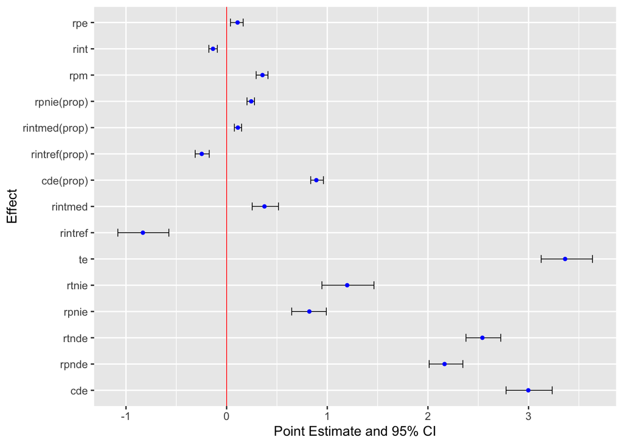

```r
fit_cmest |> ggcmest() +
  coord_flip(xlim = NULL, ylim = NULL, expand = TRUE, clip = "on")
```

# 7 3要素や4要素への分解

これまでは因果効果を直接効果や間接効果に分解する方法を学んできた．このような2要素への分解だけではなく，更に3つや4つの要素への分解も可能である．VanderWeele (2014) は$PNDE$や$TNIE$のそれぞれをさらに2つの要素に分解する方法を提案している．

$PNDE$は次の2つに分けることができる．

$$\begin{align}
PNDE & = E[Y^{am} - Y^{a^* m}] + \nonumber\\
& \quad \left(E[Y^{aM^{a^*}} - Y^{a^* M^{a^*}}] - E[Y^{am} - Y^{a^* m}]\right) \nonumber\\
&= CDE(m) + INT_{\text{ref}}(m)
\end{align}$$

$TNIE$は次の純粋間接効果と交互作用効果に分けることができる．

$$\begin{align}
TNIE &= E[Y^{a^* M^a} - Y^{a^* M^{a^* }}] + \nonumber\\
& \quad \left(E[Y^{aM^a} - Y^{aM^{a^* }}] - E[Y^{a^* M^a} - Y^{a^* M^{a^* }}]\right) \nonumber\\
&= PIE + INT_{\text{med}}
\end{align}$$

よって平均処置効果は4つの要素に分けることができる．

$$\begin{align}
TE & = PNDE + TNIE \\
&= CDE(m) + INT_{\text{ref}}(m) + PIE + INT_{\text{med}} \\
& = \left(E[Y^{aM^{a^*}} - Y^{a^* M^{a^*}}] - E[Y^{am} - Y^{a^* m}]\right) +
\left(E[Y^{aM^a} - Y^{aM^{a^* }}] - E[Y^{a^* M^a} - Y^{a^* M^{a^* }}]\right) \nonumber
\end{align}$$

また交互作用による部分（PAI: portion attributable to interaction）を取り出したければ，

$$\begin{align}
PAI(m) & = INT_{\text{ref}}(m) + INT_{\text{med}}
\end{align}$$

とする．よって，

$$\begin{align}
TE & = CDE(m) + PAI(m) + PIE
\end{align}$$

純粋効果を中心とした分解も可能である．これは純粋直接効果と純粋間接効果と交互作用による部分への分解である．

$$\begin{align}
TE & = PNDE + INT_{\text{med}} + PIE
\end{align}$$

またこのような分解はランダム化類似の方法を用いた場合にも適用可能である Wodtke and Zhou (2020)．

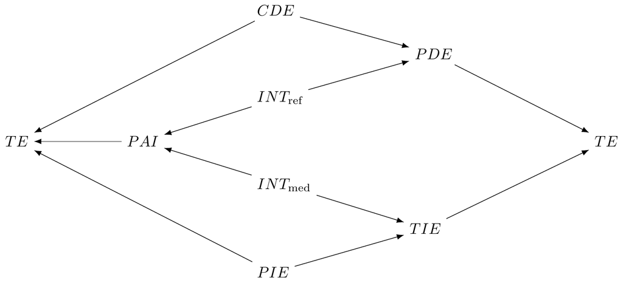

Figure 7: The 4-fold decomposition encompasses both decompositions for mediation and inteaction

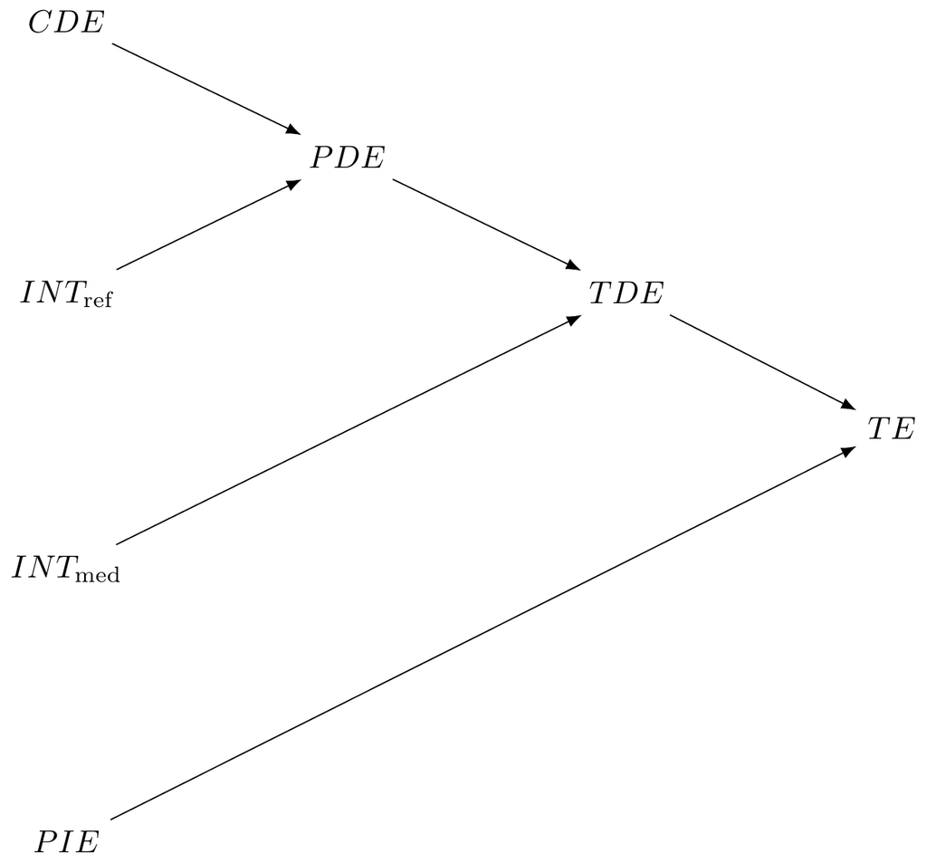

Figure 8: Alternative direct effect mediation decompositions

## References

Lundberg, Ian. 2022. “The Gap-Closing Estimand: A Causal Approach to Study Interventions That Close Disparities Across Social Categories.” *Sociological Methods & Research*, 00491241211055769. https://doi.org/10.1177/00491241211055769.

Valeri, Linda, and Tyler J. VanderWeele. 2013. “Mediation Analysis Allowing for Exposuremediator Interactions and Causal Interpretation: Theoretical Assumptions and Implementation with SAS and SPSS Macros.” *Psychological Methods* 18 (2): 137–50. https://doi.org/10.1037/a0031034.

VanderWeele, Tyler J. 2014. “A Unification of Mediation and Interaction: A 4-Way Decomposition.” *Epidemiology* 25 (5): 749–61. https://doi.org/doi: 10.1097/EDE.0000000000000121.

Vanderweele, Tyler J., and Stijn Vansteelandt. 2009. “Conceptual Issues Concerning Mediation, Interventions and Composition.” *Statistics and Its Interface* 2 (4): 457–68. https://doi.org/10.4310/SII.2009.v2.n4.a7.

VanderWeele, Tyler J., Stijn Vansteelandt, and James M. Robins. 2014. “Effect Decomposition in the Presence of an Exposure-Induced Mediator-Outcome Confounder:” *Epidemiology* 25 (2): 300–306. https://doi.org/10.1097/EDE.0000000000000034.

Wodtke, Geoffrey T., and Xiang Zhou. 2020. “Effect Decomposition in the Presence of Treatment-induced Confounding: A Regression-with-residuals Approach.” *Epidemiology* 31 (3): 369–75. https://doi.org/10.1097/EDE.0000000000001168.